# Breeding bird indicators

[NO_BIRD_001] (farmland and open lowland)  
[NO_BIRD_002] (mountains)  
[NO_BIRD_003] (wetlands)  
[NO_BIRD_004] (forests)

Authors

Affiliation

Chloé R. Nater

Norwegian Institute for Nature Research

Diego Pavón-Jordán

Norwegian Institute for Nature Research

Anders L. Kolstad

Norwegian Institute for Nature Research

Published

February 3, 2025

**Status**

This indicator documentation is complete, and indicator values can be calculated as described below.

> **Recomended citation**: Nater, C.R., Pavón-Jordán, D., Kolstad, A.L. . Breeding bird index (ID: NO_BIRD_001) v. 000.002. ecRxiv: https://github.com/NINAnor/ecRxiv/tree/main/indicators/NO_BIRD_001-004

> **Version**: 000.002

**Show metadata**

Table 1: Indicator metadata

| Indicator ID | NO_BIRD_001 |
| --- | --- |
| Indicator Name | Breeding bird index |
| Country | Norway |
| Continent | Europe |
| Ecosystem Condition Typology Class | B1 - Compositional State Characteristics |
| Realm | Terrestrial (T) |
| Biome | T2 Temperate-boreal forests and woodlands biome |
| Biome | T3 Shrublands and shrubby woodlands biome |
| Biome | T6 Polar-alpine (cryogenic) biome |
| Biome | T7 Intensive land-use biome |
| status | complete |
| Version | 000.002 |
| s | This is the first ecRxov version, but very similar indices have been used for a long time in many different settings. |
| url | https://github.com/NINAnor/ecRxiv/tree/main/indicators/NO_BIRD_001-004 |
| Normalised | No |
| Spatial aggregation pathway | Aggregate |

**Logg**

- Oct. 2023 - Complete workflow [described](https://ninanor.github.io/ecosystemCondition/breeding-birds.html)
- 3 Feb. 2025 - Started restructuring documentation for ecRxiv and updating indicator values

## 2. About the underlying data

These indicators are based on a shared data set originating from the Norwegian Breeding Birds Monitoring Program ([*Hekkefulgovervåkingen*](https://hekkefuglovervakingen.nina.no/), previously TOV-E) (Kålås et al. 2022). This is a national bird census monitoring program, origination gradually from 2005 to about 2011, with 492 sampling locations thought the country, each with 12 - 20 sampling points. About 80% of the sampling locations are visited yearly. The data are gathered mostly by experienced volunteer bird-watchers following a [standardized sampling protocol](https://hekkefuglovervakingen.nina.no/Fugl/public/papirskjema/MethodologyEng.pdf). Observers will visit each route once a year between 20. May and 10. June (depending on latitude) and carry out the census in good weather conditions. The sampling locations are selected randomly withing each of five regions: east, south, west, cnetral, and northern Norway. Note that becaus eof the standardised way that the R scripts for the TRIM analyses are made, we have not been able to account for this spatial structure in the data, for example by doing some post-stratification.

The observers record any bird seen or heard during 5 minutes at each of the pre-selected counting points in the route (see below for further information on the sampling design). A total of 229 species are typically recorded during this census. After 5 minutes, the observer walks to the next point in a straight line (when possible). During this ‘transect’ the observer is requested to record also a subset of species that are considered rare or difficult to capture during the 5-minute point counts (n = 121).

The data are entered into a [database](https://hekkefuglovervakingen.nina.no/Fugl/Default.aspx) and quality-checked by NINA. Subsequently, the raw data are processed using a combination of country-specific wrangling routines and internationally standardized scripts distributed by PECBMS, the [Pan European Bird Monitoring Scheme](https://pecbms.info/), which together make up the now integrated workflow below:

TRIM: [TRends and Indices for Monitoring data (TRIM)](https://pecbms.info/methods/software/trim/) is a freeware program developed by Statistics Netherlands in the framework of wildlife statistics

RTRIM: A set of three R script used for doing TRIM analyses. Versions exist for execution in shell and in R. See [here](https://pecbms.info/methods/software/trim/)

RSWAN: A tool for combining TRIM output data.

MSI: Multi-species index

### 2.1 Spatial and temporal resolution and extent

The bird monitoring program was established in 2005 in central Norway and expanded from there to reach full national coverage by 2010. For many species, data are already of good coverage and high quality starting in 2008. The monitoring scheme is still ongoing as of 2025.

A predecessor monitoring scheme existed prior to the establishment of “hekkefuglovervåkingen” and led to the collection of decent data in the period from 1996 up to and including 2008. Although the predecessor monitoring programmes and “hekkefuglovervåkingen” are not the same, the overlap for the years 2007 and 2008 makes it possible to combine abundance indices from across time using tools like “RSWAN”, which is provided by PECBMS. For a subset of 55 species, longer time-series of abundance indices (1996-2023, as of now) are therefore available. We have, however, not included this data in the current version of this condition variable.

As per now, the breeding bird indicators are calculated at the national scale only and the data are therefore not linked to any geofiles here. We note that some species may be sufficiently common and have enough data to allow for calculating indicator values for two major regions, Northern Norway and Southern Norway, but this requires careful evaluation that needs to be planned and organized as part of a future project.

### 2.2 Original units

The observers in the field record “number of individuals” seen or heard during the census. Those values are then converted into “number of pairs” by multiplying the number of individuals by a conversion factor, which is 2 or 5 depending on the species (for national reporting only). In the first step of the workflow, the raw counts are converted into species-specific abundance indices, defined as % of change relative to the population in a given baseline year (in Norway this is typically 2008). The abundance indices then form the basis of further analyses and aggregation routines.

### 2.3 Additional comments about the dataset

NINA performs quality-checks of the data delivered by the observers to ensure that the new data entered to the database are reliable. In addition, NINA completes the annual dataset by entering the zeroes (undetected species) at surveyed routes and -1s (for not surveyed routes). This ensures that all species have data (either a positive count, a zero or a -1) for each route and year.

From all species recorded within the *Norsk Hekkefuglovervåking* monitoring scheme (n = 229), 85 have sufficient data for abundance trend analyses. Abundance indices of 71 of those species, representing those with wide distributions and high continental-scale relevance, are reported annually to PECBMS. Longer (combined) time series can be calculated for 55 species, and 54 of those serve as indicators in the Norwegian Nature Index (Jakobsson and Pedersen 2020). The established breeding bird indicators (condition variables in SEEA EA terminology) contain varying numbers of species: the farmland bird index has 7 species, the mountain bird index has 8 species, and the forest bird index has 24 species. For the new index for wetland birds, we used 7 out of the 8 species suggested for this purpose (Husby and Kålås 2011). The one species we dropped was the Common Crane *(Grus grus)* as it has seen strong recent population increases that are linked to anthropogenic impacts unrelated to the status of their wetland breeding habitats (Bård Stokke, pers. communication).

## 3. Indicator properties

### 3.1 Ecosystem Condition Typology Class (ECT)

B1 – Compositional state characteristics.

### 3.2 Ecosystem condition characteristic

The metric is aimed at describing a characteristic of ecosystems in good condition as having high and stable bird populations.

### 3.3 Other standards

The metric is categorised under *biologisk mangfold* in the Norwegian classification system (Nybø and Evju (red) 2017). It is important to note though that the indicators represent species abundance (trends) in this context and are **not** indicators of species richness or species distribution.

### 3.4 Collinearities with other indicators

None that we consider very obvious or problematic, excep if one chose to produce a parallel bird index based on individual bird indicators from the Norwegian Nature Index (see Section 4.2).

### 3.5 Impact factors

Birds are affected by a large range of both natural and anthropogenic stressors, and what stressors are most important will vary from species to species. In general, across all species, and of the human caused impact factors, we can mention, climate change, insect declines, and land-use change (e.g. habitat loss, reduced connectivity, edge effects).

## 4. Reference condition and levels

### 4.1 Reference condition

In Norway, the reference condition for natural ecosystems have been one of largely intact ecosystems without large-scale human modifications (Nybø and Evju (red) 2017). For semi-natural ecosystems, human influence is allowed, and indeed a prerequisite, but then in the sense of appropriate, stable and traditional land-use practices. Fro agricultural ecosystems we lack a precise definition for a reference condition. The metrics are not normalised, and therefore there is no direct way to compare the values to a reference condition.

### 4.2 Reference levels

None. Note that the use of a baseline year to center the trend analyses is not equivalent to the use of reference levels, and do not allow quantitative statement of the type *this value is very high/low.* Note also that reference levels for individual bird species has been set in the Norwegian Nature Index, and it is possible to compile similar normalised bird indices by combining these single bird indicators (see Nybø et al. 2023, 55) .

## 5. Uncertainties

One source of uncertainty comes from the assumption that multi-species abundance indices use a representative selection of species sampled in a representative set of habitats. However, due to resource- and logistic constraints, that is often not the case and non-random sampling along, for example, rural-urban gradients may bias breeding bird indices derived from data from “hekkefuglovervåkingen” (Husby, Hoset, and Butler 2020).

## 6. References

Bogaart, Patrick, Mark van der Loo, and Jeroen Pannekoek. 2020. *Rtrim: Trends and Indices for Monitoring Data*. https://CRAN.R-project.org/package=rtrim.

Husby, Magne, Katrine S. Hoset, and Simon Butler. 2020. “Non-random sampling along ruralurban gradients may reduce reliability of multi-species farmland bird indicators and their trends.” *579-592*. https://doi.org/10.1111/ibi.12896.

Husby, Magne, and John Atle Kålås. 2011. *Terrestriske fuglearter som indikatorer for bærekraftig utvikling i Norge: tilstanden i ulike naturtyper og effekter av klimaendring*. https://nordopen.nord.no/nord-xmlui/handle/11250/146439.

Jakobsson, Simon, and Bård Pedersen. 2020. *Naturindeks for Norge 2020. Tilstand og utvikling for biologisk mangfold*. Norsk institutt for naturforskning (NINA). https://brage.nina.no/nina-xmlui/handle/11250/2686068.

Kålås, John Atle, Ingar Jostein Øien, Bård Gunnar Stokke, and Roald Vang. 2022. “Norsk hekkefuglovervåking 2021 (TOV-E)” NINA Rapport 2117. https://brage.nina.no/nina-xmlui/handle/11250/2988555.

Nybø, Signe, and Marianne Evju (red). 2017. *Fagsystem for Fastsetting Av God Økologisk Tilstand - Forslag Fra Et Ekspertråd*. Ekspertrådet for Økologisk Tilstand. https://www.regjeringen.no/no/dokumenter/fagsystem-for-fastsetting-av-god-okologisk-tilstand/id2558481/.

Nybø, Signe, Anders L. Kolstad, Hanno Sandvik, Vegar Bakkestuen, Marianne Evju, Erik Framstad, Matthew Grainger, et al. 2023. “Indikatorer for økologisk tilstand i våtmark, semi-naturlig mark og naturlig åpne områder under skoggrensa,” NINA Rapport, 2336. https://brage.nina.no/nina-xmlui/handle/11250/3096724.

Soldaat, Leo L., Jeroen Pannekoek, Richard J. T. Verweij, Chris A. M. van Turnhout, and Arco J. van Strien. 2017. “A Monte Carlo Method to Account for Sampling Error in Multi-Species Indicators.” *Ecological Indicators* 81 (October): 340–47. https://doi.org/10.1016/j.ecolind.2017.05.033.

## 7. Datasets

### 7.1 Dataset A - Norsk Hekkefulgovervåking

Data is downloaded from the [internal NINA database](https://hekkefuglovervakingen.nina.no/Fugl/Default.aspx?ReturnUrl=/Fugl/). See Section 2 for details on the dataset.

## 8. Spatial units

The sampling locations are selected with a regional stratification, but we do not try to account for this spatial structure here (see Section 2 for discussion). Therefore the only spatial unit we rely on the the national scale (the ecosystem accounting area).

## 9. Analyses

### Workflow setup

The code for the following analyses has been developed in a separate GitHub repository: https://github.com/NINAnor/birdIndicators As a first step, we therefore need to read in all the functions from that repository. The repository has not been converted into a package yet, so we need to download the entire repository and source all function files in the “R” folder manually:

**Download functions from GitHub repository**

```r
temppath <- here::here("indicators/NO_BIRD_001-004/temp")
destpath <- paste0(temppath, "/birdIndicators_Repo.zip")

if(!file.exists(destpath)) {
  download.file(url = "https://github.com/NINAnor/birdIndicators/archive/refs/heads/main.zip",
               destfile = destpath)
  unzip(zipfile = destpath,
       exdir = temppath)
}

sourceDir <- function(path, trace = TRUE, ...) {
  for (nm in list.files(path, pattern = "[.][RrSsQq]$")) {
    if(trace) cat(nm,":")
    source(file.path(path, nm), ...)
    if(trace) cat("\n")
  }
  invisible()
}
sourceDir(paste0(temppath, "/birdIndicators-main/R"))
```

Next, we need to define a range of relative and absolute directories. The main reason for that is that many of the scripts delivered by PECBMS function by iteratively writing and reading files in a specific folder structure. We use `here::here()` to go from relative to absolute paths. While all code would ideally be rewritten to work with relative paths and without toggling working directories, PECBMS tends to distribute new versions of their scripts periodically and with no formal version control in place. This means that it is imperative to leave their core code as untouched as possible to facilitate including new versions (by copy paste) as they come.

**Create local directories**

```r
## Absolute path for root folder:
wd <- here::here("indicators/NO_BIRD_001-004")

# Storage of raw PECBMS Trim outputs
folder <- paste0(wd, "/PECBMS_Files")

# Storage of processed PECBMS Trim outputs
subFolderName <- "Species_files"

# general and working folders
 general_folder_rel <- paste0(wd, "/temp/birdIndicators-main/data")
 working_folder_rel <- paste0(folder, "/", subFolderName)

# Storage of MSI results
MSI_results_folder <- paste0(wd, "/MSI_Results")

# NINAs local storage of legacy Trim output files
legacyFile_folder <- "P:/41201612_naturindeks_2021_2023_database_og_innsynslosning/Hekkefugl_Dataflyt/LegacyFiles_PECBMS_Trim"

# Absolute data and output paths for RSWAN (not needed)
# general_folder <- general_folder_rel
# working_folder <- working_folder_rel
# output_folder <- paste0(working_folder, "/output/")
# output_folder2 <- paste0(working_folder, "/output")


## Create directories if they are not available
dir.list <- c(
  folder,
  general_folder_rel,
  working_folder_rel
  )

for(i in 1:length(dir.list)){
  if(!file.exists(dir.list[i])){
  dir.create(dir.list[i])
  }
}
```

### Data sets

The workflow uses the up-to-date raw data from the Norwegian bird monitoring. One can also combine this with the calculated abundance indices from the predecessor monitoring scheme in Norway, and that way get a longer time series, but we will not do that here. Additionally, we also use a couple of lists holding information on which species (and years) are to be included in which parts of the analytical workflow as the different outcomes require different information.

### Monitoring data

The route-based raw data from “hekkefuglovervåking” are compiled after each breeding season and curated and stored in NINA’s database. Before storing new data in the database, a thorough quality-check is performed. From that database we download the data relevant for the [PECBMS Trim analyses](https://pecbms.info/methods/software/trim/) and for the specified range of years (here from 2008 up to and including 2024). The function `downloadData_TRIM` does that for a specified year range (from minYear up to and including maxYear), and requires specifying which driver is used for accessing the database (via argument DriverName). When running from the NINA RStudio server, we need to use “FreeTDS”. When running locally from NINA computers, we need to select “SQL Server”. Note that downloading these data requires user-specific access privileges which can be requested from NINA IT department (‘datahjelp’).

**Download Trim data from NINA database**

```r
minYear <- 2008
maxYear <- 2024

Trim_data <- downloadData_TRIM(
  minYear = minYear,
  maxYear = maxYear,
  drop_negativeSpp = TRUE,
  # DriverName = "FreeTDS"
  DriverName = "SQL Server"
  )
# save temp file
saveRDS(Trim_data, file = paste0(wd, "/temp/Trim_data.rds"))
```

### Lists of species information

The species list files should have been downloaded together with the rest of the birdIndicators repository (Section 9.1) and we can use `makeSpeciesLists()` to assemble the information.

**Assemble species lists**

```r
sppLists <- makeSpeciesLists(
  Trim_data = Trim_data,
  spp_DataPath = paste0(wd, "/temp/birdIndicators-main/data"))
Spp_selection <- sppLists$sppData

# save data
saveRDS(sppLists, file = paste0(wd, "/data/sppLists.rds"))
saveRDS(Spp_selection, file = paste0(wd, "/data/Spp_selection.rds"))
```

The table `Spp_selection` contains information for each species on which reporting routes should be included in. The multi-species indices are grouped into a single category (“MSI”) here, but we can extract the species that go into the MSI for each ecosystem via the additionally provided lists.

Farmland MSI species:

- Alauda arvensis
- Emberiza citrinella
- Hirundo rustica
- Motacilla alba
- Numenius arquata
- Sturnus vulgaris
- Vanellus vanellus

Forest MSI species:

- Anthus trivialis
- Certhia familiaris
- Dendrocopos major
- Dryocopus martius
- Erithacus rubecula
- Fringilla coelebs
- Garrulus glandarius
- Hippolais icterina
- Lophophanes cristatus
- Muscicapa striata
- Periparus ater
- Phoenicurus phoenicurus
- Phylloscopus collybita
- Phylloscopus trochilus
- Poecile montanus
- Prunella modularis
- Pyrrhula pyrrhula
- Regulus regulus
- Sylvia atricapilla
- Sylvia borin
- Turdus iliacus
- Turdus merula
- Turdus philomelos
- Turdus viscivorus

Mountain MSI species:

- Anthus pratensis
- Calcarius lapponicus
- Lagopus lagopus
- Lagopus muta
- Luscinia svecica
- Oenanthe oenanthe
- Pluvialis apricaria
- Turdus torquatus

Wetlands MSI species:

- Emberiza schoeniclus
- Gallinago gallinago
- Motacilla flava
- Numenius phaeopus
- Tringa glareola
- Tringa nebularia
- Tringa totanus

### PECBMS RTRIM analyses

In the next step, the downloaded raw data (see Section 9.3) is analysed and converted into species-specific abundance indices using the RTRIM approach (“**TR**ends and **I**ndices for **M**onitoring data” (Bogaart, van der Loo, and Pannekoek 2020)). The RTRIM analyses are run for a subset of 85 species which have sufficient data for it using the standardized scripts provided by PECBMS (more information on https://pecbms.info/methods/software/trim/). For the application here, we have written wrapper function around the PECBMS code for each step of the RTRIM workflow.

**TRIM analyses**

```r
# Write PECBMS arguments input files for each species
# These are called *_arg_input_stratum under PECBMS_Files
argument_file <-
  setupInputFiles_PECBMS_trimShell(
    Spp_selection = Spp_selection,
    folderPath = folder)

## Subset data to contain only relevant species
PECBMS_data <-
  makeInputData_PECBMS(
    Trim_data = Trim_data,
    Spp_selection = Spp_selection,
    convertNA = TRUE,
    save_allSppData = TRUE,
    returnData = TRUE,
    wd = wd)

## Run analyses using the PECBMS Rtrim shell
runRtrimShell_PECBMS(folder = folder)

## Process results
# Returns file called all_Indices_All_Trends in PECBMS_Files
trimResults_PECBMS <- processRtrimOutput_PECBMS(folder = folder)
```

The results of the the RTRIM workflow are a series of .csv and .txt files. Here we copied hem into a designated folder:

**Copy and rename files files**

```r
## Collect (and rename) species and summary files
collectSpeciesFiles_PECBMS(
  folder = folder,
  subFolderName = subFolderName)
```

### Aggregation to multi-species indices (MSIs)

The breeding bird indicators for ecosystem condition accounts / assessments are multi-species indices (MSIs) calculated following the guidelines from PECBMS (https://www.cbs.nl/en-gb/society/nature-and-environment/indices-and-trends–trim–/msi-tool) and using the algorithm of Soldaat et al. (2017).

The function for calculating MSIs requires specifying whether or not to make use of combined time series generated by RSWAN (argument `useCombTS`), which year to use as a base/reference (argument `baseYear`), and which year to use as a changepoint (argument `changepointYear`).

We are not including data from the bird monitoring that was in effect before the current *Hekkefulgovervåkinga*, and therefore we do not need to use the RSWAM method to combine time series.

The choice of change point year does not affect index values, but specifies until and from which year additional, shorter term trends should be calculated (i.e. if `changepointYear = 2008`, the procedure will additionally provide trend estimates from starting year to 2008, and from 2008 to the last year in the data). We set this to 2022 below because we have to set something, but we will not investigate this part of the analyses any further.

```r
useCombTS <- FALSE
baseYear <- 2010
changepointYear <- 2022
```

The function also requires us to provide a name (argument) and a list of EURING codes of species to include (argument). We list these for all four ecosystem indices:

```r
IndexNames <- c("FarmlandBirds", "ForestBirds", "MountainBirds", "WetlandBirds")
Index_sppLists <- list(sppLists$sppLists$MSI_farmland,
                       sppLists$sppLists$MSI_forest,
                       sppLists$sppLists$MSI_mountain,
                       sppLists$sppLists$MSI_wetlands)
```

**Calculate MSI values**

```r
MSI_longTerm <- data.frame()

for(i in 1:4){
  message(paste0(crayon::bold("Calculating ", IndexNames[i], " Index...")))
  results <- calculateIndex_MultiSpecies(working_folder = working_folder_rel,
                                         Spp_subset = Index_sppLists[[i]],
                                         IndexName = IndexNames[i],
                                         results_folder = MSI_results_folder,
                                         useCombTS = useCombTS,
                                         baseYear = baseYear,
                                         changepointYear = changepointYear)
  MSI_longTerm <- rbind(MSI_longTerm, results)
  message("")
}
# save output
saveRDS(MSI_longTerm, file = paste0(wd, "/data/MSI_results.rds"))
```

The MSI is provided both as point estimates (`MSI`) with associated standard error (`sd_MSI`) and confidence interval (`lower_CL_MSI` and `upper_CL_MSI`), and as a smoothed trend model fit (characterised by an average trend, `Trend`, and an associated confidence interval, `lower_CL_trend` and `upper_CL_trend`):

Additionally, the results are saved as a standardized set of files used for reporting to PECBMS.

We can now visualize the results both as point estimates and trend fit:

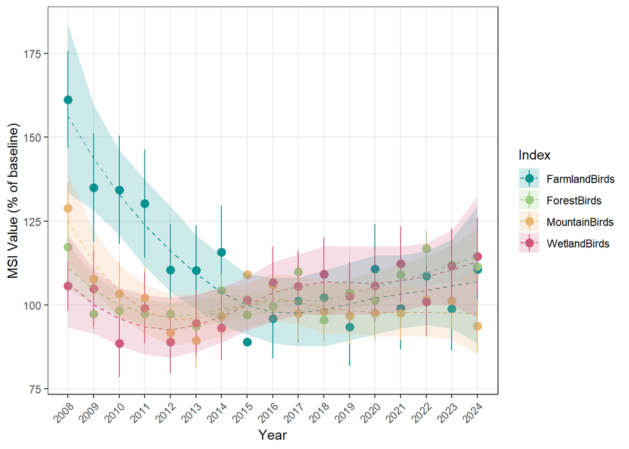

```r
myplotTimeSeries_MSI <- function(MSI, results_folder){

  ## Define custom colors
  plotCols <- colorspace::divergingx_hcl(palette = "Temps", n = length(unique(MSI$IndexName)))

  p2 <- ggplot(MSI, aes(x = year, y = MSI)) +
    geom_point(aes(colour = IndexName), size = 3) +
    geom_pointrange(aes(ymin = MSI - sd_MSI, ymax = MSI + sd_MSI, colour = IndexName)) +
    geom_line(aes(y = Trend, colour = IndexName), linetype = "dashed") +
    geom_ribbon(aes(ymin = lower_CL_trend, ymax = upper_CL_trend, fill = IndexName), alpha = 0.2) +
    scale_x_continuous(name = "Year", breaks = min(MSI$year):max(MSI$year)) +
    scale_color_manual(name = "Index", values = plotCols) +
    scale_fill_manual(name = "Index", values = plotCols) +
    ylab("MSI Value (% of baseline)") +
    theme_bw() +
    theme(panel.grid.minor = element_blank(),
          axis.text.x = element_text(angle = 45, hjust = 1))

    print(p2)
  }



myplotTimeSeries_MSI(
  MSI = MSI_results,
  results_folder = MSI_results_folder
                   )
```

### Choise of metric to represent accounting period

The MSI should ideally be interpreted as time series (e.g. from looking at Figure 1). However, ecosystem accounting tables are limited in how they can convey temporal trends. Usually this is limited to a starting and closing value. The value for a gives year (point estimates) can fluctuate due to natural variation (e.g. weather events) and may not reflect any long or medium term trend in ecosystem condition. The MSI trend is better at smoothing out these interannual trends. However, it may be too good at smoothing out these trends, and we want to avoid data from previous accounting periods to affect subsequent periods. Our solution is to use the mean of the MSI point estimates from the years inside each accounting period (three year periods). Errors are aggregated by simulating values for each time step. assuming a normal distribution, and sampling equally from each. We must stress that the absolute variable value for an accounting period is only interprettable as a short term trend in the data, and to not indicate whether this value is especial high or low compared to historical values or any desirable state.

> We must stress that the absolute variable value for an accounting period is only interprettable as a short term trend in the data, and to not indicate whether this value is especial high or low compared to historical values or any desirable state.

These bird indices are variables in the SEEA EA terminology and should be reported in the variable account.

## 10. Results

```r
output <- MSI_results |>

# errors are 0 in 2015 so we will not use that year, or any year before, at least not for this excercise
  filter(year > 2015) |>

# creating three accounting periods
  mutate(accounting_period_final_year = case_when(
    year <= 2018 ~ 2018,
    year <= 2021 ~ 2021,
    year <= 2024 ~ 2024,
    .default = NA
      )) |>
  mutate(accounting_period = case_when(
    year <= 2018 ~ "2016-2018",
    year <= 2021 ~ "2019-2021",
    year <= 2024 ~ "2022-2024",
    .default = NA
      )) |>

# create probability distributions for each point estimate,
# assuming a normal distribution
  rowwise() |>
  mutate(
    dist = list(rnorm(10000, MSI, sd_MSI))) |>

# sample 9000 observations randomly across the three years
# inside each accountin period to get a shared distribution
  group_by(IndexName, accounting_period_final_year, accounting_period) |>
    reframe(
      variableValue = mean(MSI),
      dist = list(sample(
        unlist(dist),
        size = 9000,
        replace = TRUE))) |>

# get the 25th and 75th percentile from this shared distribution
  ungroup() |>
  rowwise() |>
  mutate(
    "75th percentile" = quantile(unlist(dist), 0.75),    # ERROR
    "25th percentile" = quantile(unlist(dist), 0.25),

 # Add some variables for the final table
    ID = case_when(
      IndexName == "FarmlandBirds" ~ "NO_BIRD_001",
      IndexName == "ForestBirds" ~ "NO_BIRD_004",
      IndexName == "MountainBirds" ~ "NO_BIRD_002",
      IndexName == "WetlandBirds" ~ "NO_BIRD_003"
    ),
    ecosystem = case_when(
      IndexName == "FarmlandBirds" ~ "Farmland & Open lowland",
      IndexName == "ForestBirds" ~ "Forests",
      IndexName == "MountainBirds" ~ "Alpine",
      IndexName == "WetlandBirds" ~ "Wetlands"
    )) |>
  add_column(
    ECT = "B1",
    "Accounting area" = "Norway") |>

# Select which columns to show, and set their order
  select(
    Indicator = IndexName,
    ID,
    ECT,
    "Accounting area",
    "Accounting period" = accounting_period,
    "Variable value" = variableValue,
    "25th percentile",
    "75th percentile")

# print table
output |>
    kbl()
```

| Indicator | ID | ECT | Accounting area | Accounting period | Variable value | 25th percentile | 75th percentile |
| --- | --- | --- | --- | --- | --- | --- | --- |
| FarmlandBirds | NO_BIRD_001 | B1 | Norway | 2016-2018 | 99.74333 | 91.24730 | 108.0371 |
| FarmlandBirds | NO_BIRD_001 | B1 | Norway | 2019-2021 | 101.02667 | 90.74077 | 110.3656 |
| FarmlandBirds | NO_BIRD_001 | B1 | Norway | 2022-2024 | 105.99000 | 96.70667 | 115.6675 |
| ForestBirds | NO_BIRD_004 | B1 | Norway | 2016-2018 | 101.62667 | 95.77505 | 107.3930 |
| ForestBirds | NO_BIRD_004 | B1 | Norway | 2019-2021 | 104.61667 | 100.54629 | 108.5008 |
| ForestBirds | NO_BIRD_004 | B1 | Norway | 2022-2024 | 113.42333 | 109.64039 | 117.2820 |
| MountainBirds | NO_BIRD_002 | B1 | Norway | 2016-2018 | 100.46667 | 94.03998 | 106.6619 |
| MountainBirds | NO_BIRD_002 | B1 | Norway | 2019-2021 | 97.35000 | 91.85823 | 102.8900 |
| MountainBirds | NO_BIRD_002 | B1 | Norway | 2022-2024 | 98.80000 | 92.46725 | 104.9310 |
| WetlandBirds | NO_BIRD_003 | B1 | Norway | 2016-2018 | 107.12333 | 99.75033 | 114.0891 |
| WetlandBirds | NO_BIRD_003 | B1 | Norway | 2019-2021 | 106.81667 | 98.88574 | 114.5455 |
| WetlandBirds | NO_BIRD_003 | B1 | Norway | 2022-2024 | 109.05667 | 100.58131 | 117.4387 |